# GH1054171

M504 - AI and Applications

Rosemarie Exile

GH1054171

```
                                                GLOBAL CYBERSECURITY THREATS
```

Project Brief

The rapid growth of Artificial Intelligence (AI) has affected many industries. With these technological advancements, cybersecurity measures need to continuously evolve and improve. This project examines global cybersecurity threats affecting industries. It aims to provide companies with insights into the most common and widely used types of cyberattacks, as well as the industries most frequently targeted. The dataset used in this project was obtained from Kaggle. The data is synthetic and is intended for educational, research, and data analytics purposes. Soundankar, A. (2025) Global Cybersecurity Threats (2015–2024). Kaggle. Available at: https://www.kaggle.com/datasets/atharvasoundankar/global-cybersecurity-threats-2015-2024/discussion/589979 (Accessed: 8 September 2026)

Business Context

This project focuses on global industries that operate using computer systems and digital technologies, particularly industries that face a high risk of financial loss in the event of a cyberattack. The analysis can help organizations become more aware of cybersecurity threats and identify areas where they can improve their overall security posture.

The project will examine the geographical locations of cyberattacks, the year in which they occurred, threat types, attack vectors, targeted industries, and their financial impact.

Business Questions?

1. In which country do cyberattacks commonly occur?
2. Does technological advancement greatly impact the growth of cyberattacks?
3. Which industry is most commonly targeted by cyberattacks?
4. How much financial loss is caused by cyberattacks each year?
5. What is the most common threat type used by hackers?
6. What is the most common attack vector used to penetrate a company’s security?
7. What are the most common types of security vulnerabilities?
8. What security tools are commonly used by industries?
9. How many users are affected by cyberattacks?
10. How does resolution time affect financial loss?

Why Data Science is Needed?

The Global Cybersecurity Project aims to achieve the following goals:

1. To enhance and strengthen the cybersecurity posture of organizations and industries.
2. To educate users on how to protect company data and information systems from cybersecurity threats.
3. To minimize the risk of financial losses resulting from cyberattacks.
4. To encourage organizations to regularly update their security tools and measures as cyberattack techniques and attack vectors continue to evolve.
5. To continuously monitor and remediate potential cybersecurity threats and reduce the risk of successful attacks.

```python
#Importing library

import numpy as np
import pandas as pd
import matplotlib.pyplot as plt
import seaborn as sns
```

```python
# Reading dataset directly from GitHub
url = "https://raw.githubusercontent.com/bluefirerose/Python/main/M504/Global_Cybersecurity_Threats_2015-2024.csv"
df = pd.read_csv(url)
```

Data Processing

```python
#Showing the last five sample data within the dataset
df.tail(5)
```

|  | Country | Year | Attack Type | Target Industry | Financial Loss (in Million $) | Number of Affected Users | Attack Source | Security Vulnerability Type | Defense Mechanism Used | Incident Resolution Time (in Hours) |
| --- | --- | --- | --- | --- | --- | --- | --- | --- | --- | --- |
| 2995 | UK | 2021 | Ransomware | Government | 51.42 | 190694 | Unknown | Social Engineering | Firewall | 52 |
| 2996 | Brazil | 2023 | SQL Injection | Telecommunications | 30.28 | 892843 | Hacker Group | Zero-day | VPN | 26 |
| 2997 | Brazil | 2017 | SQL Injection | IT | 32.97 | 734737 | Nation-state | Weak Passwords | AI-based Detection | 30 |
| 2998 | UK | 2022 | SQL Injection | IT | 32.17 | 379954 | Insider | Unpatched Software | Firewall | 9 |
| 2999 | Germany | 2021 | SQL Injection | Retail | 48.20 | 480984 | Unknown | Zero-day | VPN | 64 |

Table shows the last 5 data sample in the dataset. This shows the column and the value for each input.

```python
Exploratory Data Analysis
```

```python
#Getting the total number of records in dataset
df.shape
```

```
(3000, 10)
```

There are 3,000 data sample in the dataset and contains 10 column.

```python
#Checking dataframe summary
df.info()
```

```
<class 'pandas.core.frame.DataFrame'>
RangeIndex: 3000 entries, 0 to 2999
Data columns (total 10 columns):
 #   Column                               Non-Null Count  Dtype
---  ------                               --------------  -----
 0   Country                              3000 non-null   object
 1   Year                                 3000 non-null   int64
 2   Attack Type                          3000 non-null   object
 3   Target Industry                      3000 non-null   object
 4   Financial Loss (in Million $)        3000 non-null   float64
 5   Number of Affected Users             3000 non-null   int64
 6   Attack Source                        3000 non-null   object
 7   Security Vulnerability Type          3000 non-null   object
 8   Defense Mechanism Used               3000 non-null   object
 9   Incident Resolution Time (in Hours)  3000 non-null   int64
dtypes: float64(1), int64(3), object(6)
memory usage: 234.5+ KB
```

The info shows the dataset range index, total columns, null-count, data types for each column and memory usage.

```python
#Check the unique value in a column
df.nunique()
```

```
Country                                  10
Year                                     10
Attack Type                               6
Target Industry                           7
Financial Loss (in Million $)          2536
Number of Affected Users               2998
Attack Source                             4
Security Vulnerability Type               4
Defense Mechanism Used                    5
Incident Resolution Time (in Hours)      72
dtype: int64
```

This list shows te unique value entered in each column.

```python
#Check missing value
df.isnull().sum()
```

```
Country                                0
Year                                   0
Attack Type                            0
Target Industry                        0
Financial Loss (in Million $)          0
Number of Affected Users               0
Attack Source                          0
Security Vulnerability Type            0
Defense Mechanism Used                 0
Incident Resolution Time (in Hours)    0
dtype: int64
```

The list shows the null value for each column.

```python
#View data with duplicate and show the total duplicate row
print("Total duplicate rows:", df.duplicated().sum())
```

```
Total duplicate rows: 0
```

There's 0 duplicate row from the dataset. This means all rows are unique.

```python
#Descriptive and statistics of each column
df.describe()
```

|  | Year | Financial Loss (in Million $) | Number of Affected Users | Incident Resolution Time (in Hours) |
| --- | --- | --- | --- | --- |
| count | 3000.000000 | 3000.000000 | 3000.000000 | 3000.000000 |
| mean | 2019.570333 | 50.492970 | 504684.136333 | 36.476000 |
| std | 2.857932 | 28.791415 | 289944.084972 | 20.570768 |
| min | 2015.000000 | 0.500000 | 424.000000 | 1.000000 |
| 25% | 2017.000000 | 25.757500 | 255805.250000 | 19.000000 |
| 50% | 2020.000000 | 50.795000 | 504513.000000 | 37.000000 |
| 75% | 2022.000000 | 75.630000 | 758088.500000 | 55.000000 |
| max | 2024.000000 | 99.990000 | 999635.000000 | 72.000000 |

The table shows the descriptive statistics of each numerical column.

Business Question Analysis 1

1. In which country do cyberattacks commonly occur?

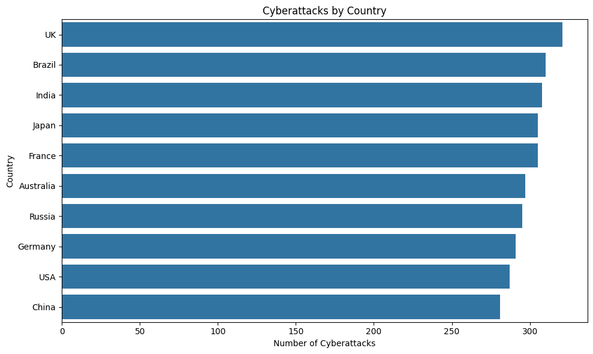

```
Cyberattacks by Country:
-----------------------------------
UK                   321
Brazil               310
India                308
Japan                305
France               305
Australia            297
Russia               295
Germany              291
USA                  287
China                281
-----------------------------------
Total Cyberattacks:  3000

Most affected country: UK
Number of attacks: 321
```

```python
# Count cyberattacks by country
country_attacks = df['Country'].value_counts()

# Total number of cyberattacks
total_attacks = country_attacks.sum()

# Create horizontal bar graph
plt.figure(figsize=(10, 6))

sns.barplot(
    x=country_attacks.values,
    y=country_attacks.index
)

plt.title('Cyberattacks by Country')
plt.xlabel('Number of Cyberattacks')
plt.ylabel('Country')

plt.tight_layout()
plt.show()


# Reference list outside the graph
print("Cyberattacks by Country:")
print("-" * 35)

for country, count in country_attacks.items():
    print(f"{country:<20} {count}")

print("-" * 35)
print(f"{'Total Cyberattacks:':<20} {total_attacks}")

# Summary
print("\nMost affected country:", country_attacks.idxmax())
print("Number of attacks:", country_attacks.max())
```

The graph shows the 10 countries where cyberattacks were identified in the dataset between 2015 and 2024. The UK had the highest number of cyberattacks during this 10-year period. Followed by Brazil, India, Japan and France. This graph helps determine which countries were targeted the most by cyberattacks over the past ten years.

Business Question Analysis 2

2. Does technological advancement greatly impact the growth of cyberattacks?

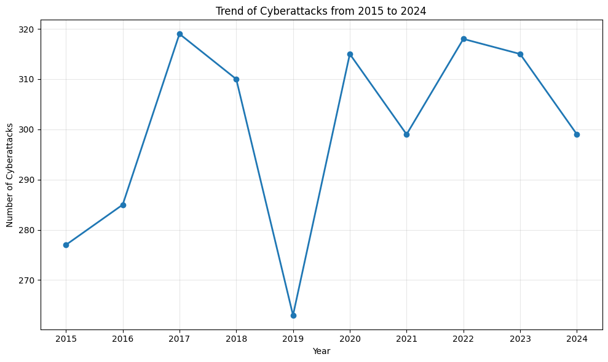

```
Year vs Cyberattack Frequency Correlation: 0.401
```

```python
#Group the attack by year
attacks_year = df.groupby('Year').size()

#Create the line graph
plt.figure(figsize=(10, 6))

plt.plot(
    attacks_year.index,
    attacks_year.values,
    marker='o',
    linewidth=2
)

plt.title('Trend of Cyberattacks from 2015 to 2024')
plt.xlabel('Year')
plt.ylabel('Number of Cyberattacks')

plt.xticks(attacks_year.index)
plt.grid(alpha=0.3)

plt.tight_layout()
plt.show()

#Compute the correlation between the year and number of attacks
correlation = np.corrcoef(
    attacks_year.index,
    attacks_year.values
)[0, 1]

print("Year vs Cyberattack Frequency Correlation:",
      round(correlation, 3))
```

Based on the general interpretation of correlation, the 0.401 has a moderate positive correlation coefficient. The graph shows threat count flactuate instead of gradually increasing every year. This means that technology advancement does not immediately mean growth of cybersecurity attack based on the dataset.

Business Question Analysis 3

3. Which industry is most commonly targeted by cyberattacks?

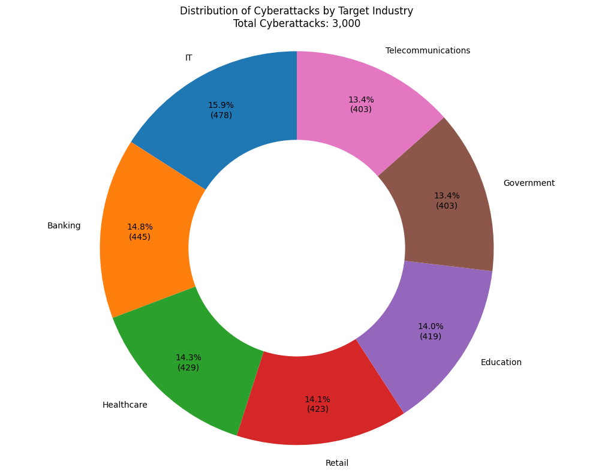

```
Cyberattacks per Industry:
Target Industry
IT                    478
Banking               445
Healthcare            429
Retail                423
Education             419
Government            403
Telecommunications    403
Name: count, dtype: int64

Total Cyberattacks: 3000
```

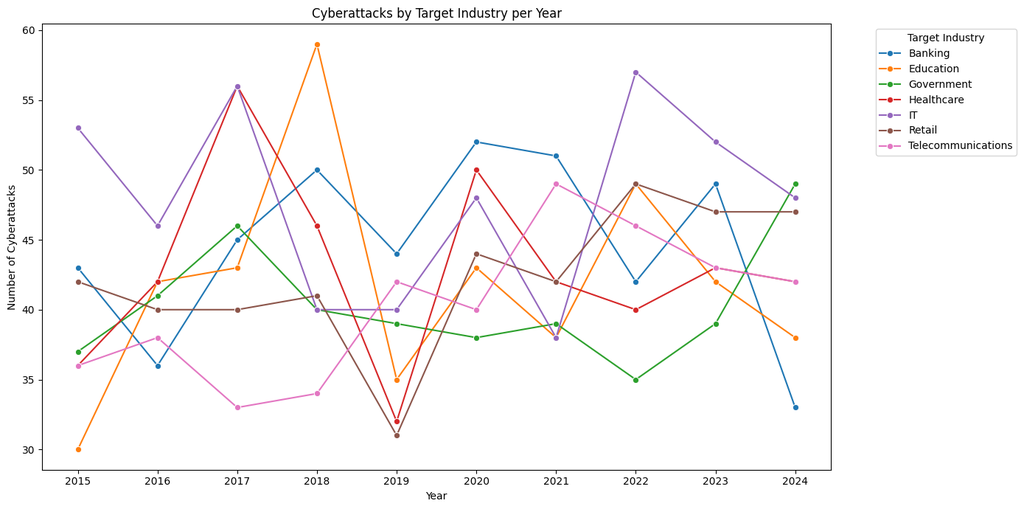

```python
# Count cyberattacks per industry
industry_attacks = df['Target Industry'].value_counts()

# Total number of attacks
total_attacks = industry_attacks.sum()

# Function to display percentage and actual count
def show_count_and_percentage(pct):
    count = int(round(pct / 100 * total_attacks))
    return f'{pct:.1f}%\n({count})'


plt.figure(figsize=(10, 8))

plt.pie(
    industry_attacks.values,
    labels=industry_attacks.index,
    autopct=show_count_and_percentage,
    startangle=90,
    pctdistance=0.80
)

# Create donut hole
centre_circle = plt.Circle(
    (0, 0),
    0.55,
    fc='white'
)

plt.gca().add_artist(centre_circle)

plt.title(
    f'Distribution of Cyberattacks by Target Industry\n'
    f'Total Cyberattacks: {total_attacks:,}'
)

plt.axis('equal')
plt.tight_layout()
plt.show()


# Display the exact count per industry
print("Cyberattacks per Industry:")
print(industry_attacks)

print("\nTotal Cyberattacks:", total_attacks)




plt.figure(figsize=(14, 7))

sns.lineplot(
    data=industry_year,
    x='Year',
    y='Number of Attacks',
    hue='Target Industry',
    marker='o'
)

plt.title('Cyberattacks by Target Industry per Year')
plt.xlabel('Year')
plt.ylabel('Number of Cyberattacks')
plt.xticks(sorted(df['Year'].unique()))

plt.legend(
    title='Target Industry',
    bbox_to_anchor=(1.05, 1),
    loc='upper left'
)

plt.tight_layout()
plt.show()
```

The IT industry shows the highest cyberattacks per industry for the past ten years, with 15.9% total cyberattacks. This means IT industries should strengthen their security posture to mitigate the risk.

```python
Business Question Analysis 4
```

4. How much financial loss is caused by cyberattacks each year?

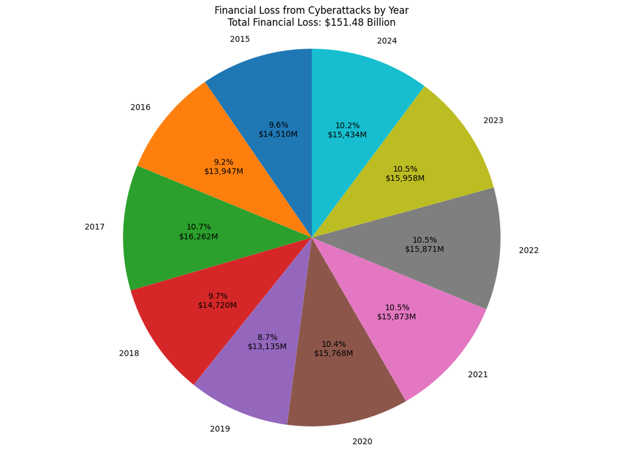

```python
financial_loss_year = (
    df.groupby('Year')['Financial Loss (in Million $)']
    .sum()
    .sort_index()
)

total_loss = financial_loss_year.sum()

def show_loss(pct):
    value = pct / 100 * total_loss
    return f'{pct:.1f}%\n${value:,.0f}M'


plt.figure(figsize=(11, 8))

plt.pie(
    financial_loss_year.values,
    labels=financial_loss_year.index,
    autopct=show_loss,
    startangle=90
)

plt.title(
    f'Financial Loss from Cyberattacks by Year\n'
    f'Total Financial Loss: ${total_loss / 1000:,.2f} Billion'
)

plt.axis('equal')
plt.tight_layout()
plt.show()
```

Approximately $151.48 billion loss for between 2015 to 2024. This shows how cyberattack costs each year for the whole industr.

Business Question Analysis 5

5. What is the most common threat type used by hackers?

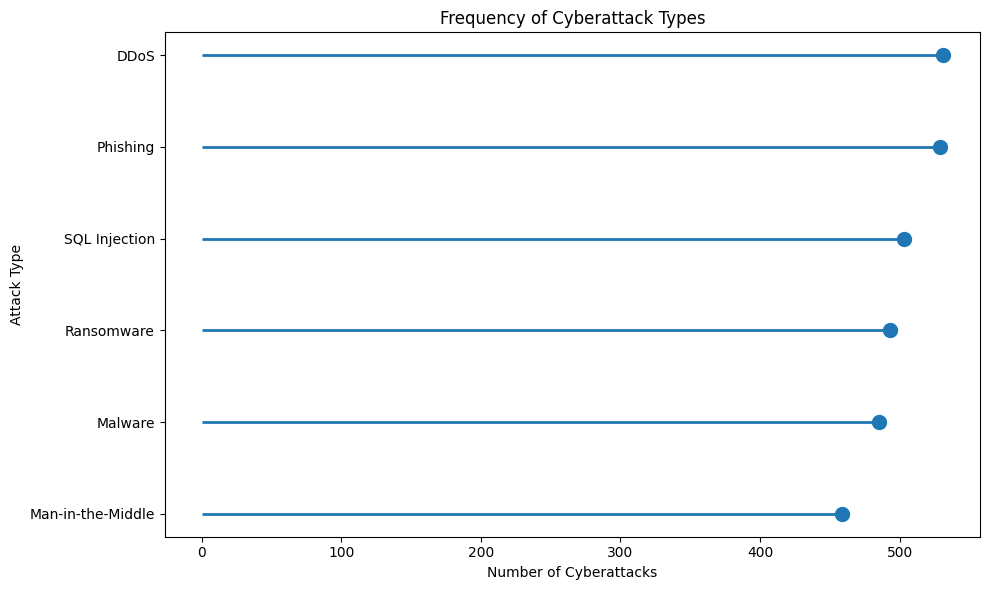

```
Attack Type
DDoS                 531
Phishing             529
SQL Injection        503
Ransomware           493
Malware              485
Man-in-the-Middle    459
Name: count, dtype: int64
```

```python
attack_types = (
    df['Attack Type']
    .value_counts()
    .sort_values()
)

plt.figure(figsize=(10, 6))

plt.hlines(
    y=attack_types.index,
    xmin=0,
    xmax=attack_types.values,
    linewidth=2
)

plt.scatter(
    attack_types.values,
    attack_types.index,
    s=100
)

plt.title('Frequency of Cyberattack Types')
plt.xlabel('Number of Cyberattacks')
plt.ylabel('Attack Type')

plt.tight_layout()
plt.show()


attack_type_counts = df['Attack Type'].value_counts()

print(attack_type_counts)
```

Here, we determined the known threat types used for security attacks. Distributed Denial of Service (DDoS) scored the highest with 531. This affects the system's availability for use. Phishing, with 529, ranked second, as with the boom of AI, there are tools that empower these attacks to be smarter or more presentable than before.

```python
Business Question Analysis 6
```

6. What is the most common attack vector used to penetrate a company’s security?

```
Attack Source  Hacker Group  Insider  Nation-state  Unknown
Year
2015                     56       68            78       75
2016                     67       59            78       81
2017                     89       73            81       76
2018                     75       86            74       75
2019                     48       73            79       63
2020                     68       87            80       80
2021                     73       74            85       67
2022                     61       90            82       85
2023                     77       69            84       85
2024                     72       73            73       81
```

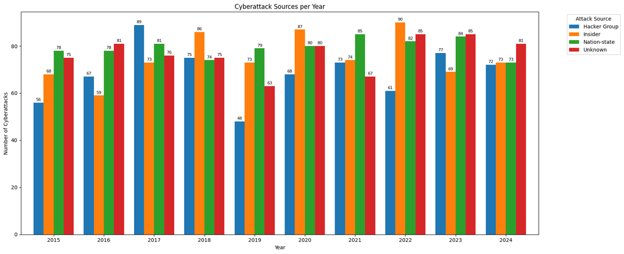

```python
# Count each attack source per year
attack_source_year = pd.crosstab(
    df['Year'],
    df['Attack Source']
)

print(attack_source_year)

# Create graph
ax = attack_source_year.plot(
    kind='bar',
    figsize=(17, 7),
    width=0.8
)

# Add count above each bar
for container in ax.containers:
    ax.bar_label(
        container,
        fontsize=8,
        padding=2
    )

plt.title('Cyberattack Sources per Year')
plt.xlabel('Year')
plt.ylabel('Number of Cyberattacks')

plt.xticks(rotation=0)

plt.legend(
    title='Attack Source',
    bbox_to_anchor=(1.05, 1),
    loc='upper left'
)

plt.tight_layout()
plt.show()
```

```python
The above graph the total number of attack source per year.
```

```
Attack Source
Nation-state    794
Unknown         768
Insider         752
Hacker Group    686
Name: count, dtype: int64
```

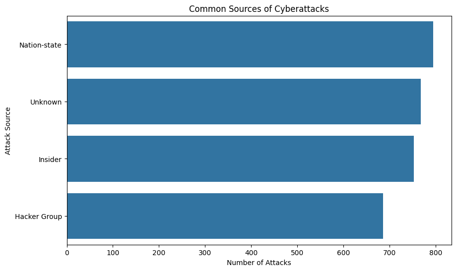

```python
attack_source_counts = df['Attack Source'].value_counts()

print(attack_source_counts)

plt.figure(figsize=(10, 6))

sns.barplot(
    x=attack_source_counts.values,
    y=attack_source_counts.index
)

plt.title('Common Sources of Cyberattacks')
plt.xlabel('Number of Attacks')
plt.ylabel('Attack Source')

plt.show()
```

We determined the overall attack source count in total for the past 10 years. Nation-state sources have led the attack count. Espionage and military advancements are possible reasons for the attacks.

```python
Business Question Analysis 7
```

7. What are the most common types of security vulnerabilities?

```
    Year Security Vulnerability Type  Number of Incidents
0   2015          Social Engineering                   68
1   2015          Unpatched Software                   71
2   2015              Weak Passwords                   53
3   2015                    Zero-day                   85
4   2016          Social Engineering                   79
5   2016          Unpatched Software                   72
6   2016              Weak Passwords                   73
7   2016                    Zero-day                   61
8   2017          Social Engineering                   74
9   2017          Unpatched Software                   75
10  2017              Weak Passwords                   80
11  2017                    Zero-day                   90
12  2018          Social Engineering                   78
13  2018          Unpatched Software                   73
```

[output cut: 26 more lines]

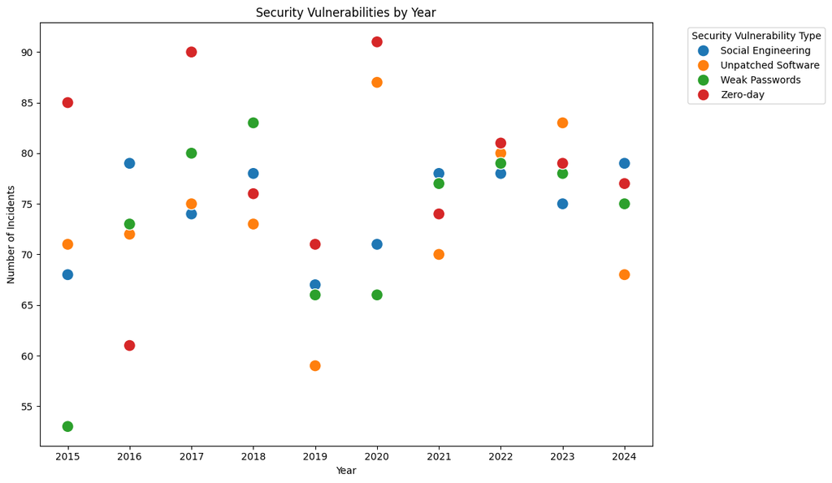

```python
# Count vulnerabilities per year
vulnerability_year = (
    df.groupby(['Year', 'Security Vulnerability Type'])
      .size()
      .reset_index(name='Number of Incidents')
)

# Display the data
print(vulnerability_year)

# Create scatter plot
plt.figure(figsize=(12, 7))

sns.scatterplot(
    data=vulnerability_year,
    x='Year',
    y='Number of Incidents',
    hue='Security Vulnerability Type',
    s=150
)

plt.title('Security Vulnerabilities by Year')
plt.xlabel('Year')
plt.ylabel('Number of Incidents')

plt.xticks(sorted(df['Year'].unique()))

plt.legend(
    title='Security Vulnerability Type',
    bbox_to_anchor=(1.05, 1),
    loc='upper left'
)

plt.tight_layout()
plt.show()
```

```
Security Vulnerability Type
Zero-day              785
Social Engineering    747
Unpatched Software    738
Weak Passwords        730
Name: count, dtype: int64
```

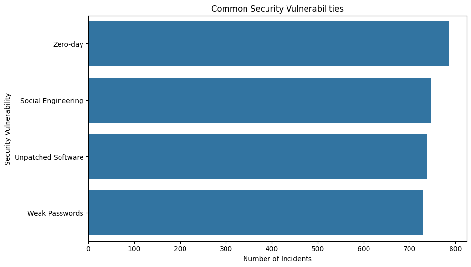

```python
vulnerability_counts = df[
    'Security Vulnerability Type'
].value_counts()

print(vulnerability_counts)

plt.figure(figsize=(10, 6))

sns.barplot(
    x=vulnerability_counts.values,
    y=vulnerability_counts.index
)

plt.title('Common Security Vulnerabilities')
plt.xlabel('Number of Incidents')
plt.ylabel('Security Vulnerability')

plt.show()
```

Zero-day vulnerability has been determined in our dataset as the most common security vulnerability, possibly due to the cost of software and tool updates.

Business Question Analysis 8

8. What security tools are commonly used by industries?

```
Defense Mechanism Used
Antivirus             628
VPN                   612
Encryption            592
Firewall              585
AI-based Detection    583
Name: count, dtype: int64
```

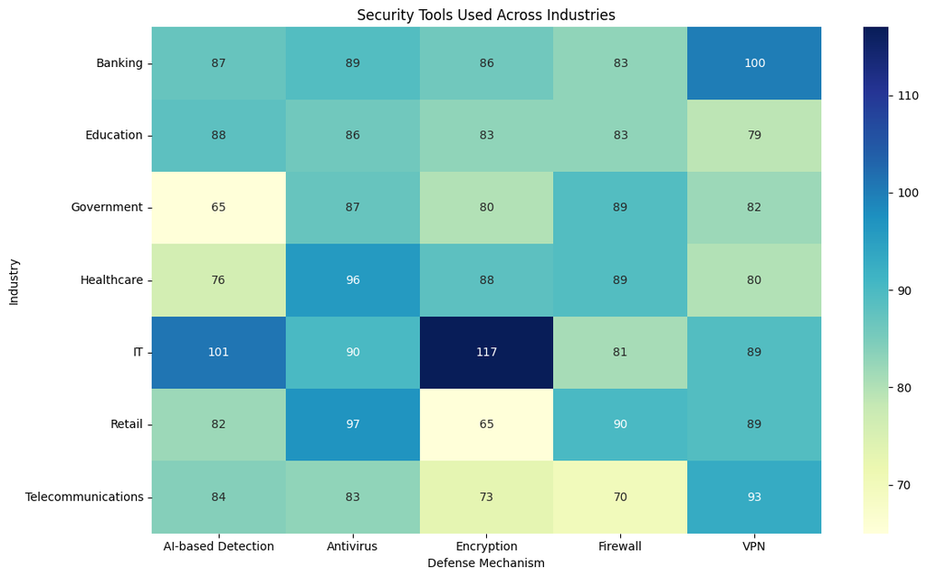

```python
defense_counts = df[
    'Defense Mechanism Used'
].value_counts()

print(defense_counts)

security_tools = pd.crosstab(
    df['Target Industry'],
    df['Defense Mechanism Used']
)

security_tools


plt.figure(figsize=(12, 7))

sns.heatmap(
    security_tools,
    annot=True,
    fmt='d',
    cmap='YlGnBu'
)

plt.title('Security Tools Used Across Industries')
plt.xlabel('Defense Mechanism')
plt.ylabel('Industry')

plt.tight_layout()
plt.show()
```

Here antivirus has greatly help differnt industries to secure their device. Heat check shows the total number of insdustries using their security tools.

Business Question Analysis 9

9. How many users are affected by cyberattacks?

```
Total affected-user instances: 1,514,052,409
```

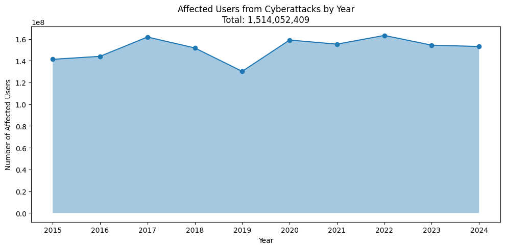

```python
users_year = (
    df.groupby('Year')['Number of Affected Users']
    .sum()
)

total_users = df['Number of Affected Users'].sum()

print("Total affected-user instances:",
      f"{total_users:,}")

plt.figure(figsize=(10, 5))

plt.fill_between(
    users_year.index,
    users_year.values,
    alpha=0.4
)

plt.plot(
    users_year.index,
    users_year.values,
    marker='o'
)

plt.title(
    f'Affected Users from Cyberattacks by Year\n'
    f'Total: {total_users:,}'
)

plt.xlabel('Year')
plt.ylabel('Number of Affected Users')

plt.xticks(users_year.index)

plt.tight_layout()
plt.show()
```

The graph shows how many users are affected due to cyberattacks. This helps organizations to improve user awareness and how not to be the weakest link in the organization.

Business Question Analysis 10

10. How does resolution time affect financial loss?

```python
correlation = df[
    'Incident Resolution Time (in Hours)'
].corr(
    df['Financial Loss (in Million $)']
)

print(
    "Correlation:",
    round(correlation, 3)
)
```

```
Correlation: -0.013
```

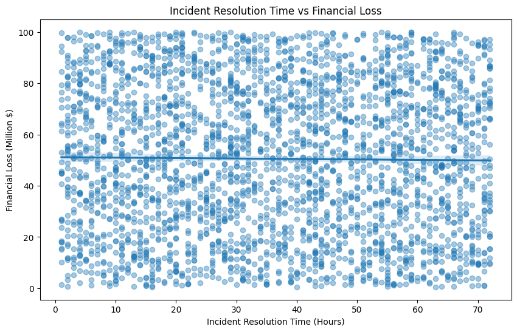

```python
plt.figure(figsize=(10, 6))

sns.regplot(
    data=df,
    x='Incident Resolution Time (in Hours)',
    y='Financial Loss (in Million $)',
    scatter_kws={'alpha': 0.4}
)

plt.title(
    'Incident Resolution Time vs Financial Loss'
)

plt.xlabel('Incident Resolution Time (Hours)')
plt.ylabel('Financial Loss (Million $)')

plt.show()
```

Correlation between resolution time and finacial loss got a result of -0.013. This means that greater time resolution does not mean greater financial loss. There is no correlation basing on the synthetic dataset we have used.

Conclusion

Overall, this exploratory data analysis showed that the UK was the most affected country by cyberattacks, while the IT industry experienced the highest number of attacks over the past 10 years. A moderate positive correlation of 0.401 was identified between year and cyberattack frequency, indicating a general tendency for cyberattacks to increase over time. However, the dataset does not directly measure technological advancement; therefore, it cannot be concluded that technological advancement affects the growth of cyberattacks.

The analysis also identified approximately $151.48 billion in total financial losses caused by cyberattacks. Distributed Denial-of-Service (DDoS) was the most common type of attack and can disrupt business operations by affecting the availability of systems and services. Nation-state actors were the most common attack source, while zero-day vulnerabilities were the most common security vulnerability. Antivirus software was the most commonly used defense mechanism for protecting computer devices.

Furthermore, a total of 1,514,052,409 affected-user instances were recorded over the 10-year period. Finally, the analysis found almost no correlation between incident resolution time and financial loss, suggesting that resolution time alone does not have a meaningful linear relationship with the financial losses recorded in this dataset.

Limitation

The dataset used in this exploratory data analysis is synthetic and intended for educational and research purposes. Therefore, the results should not be interpreted as an exact representation of real-world global cybersecurity incidents. Using reliable real-world cybersecurity data in future studies could provide more realistic findings and may support organizations in improving their Intrusion Detection Systems (IDS), Intrusion Prevention Systems (IPS), and overall cybersecurity posture.